# Pharma Project

### Минимум и максимум. Боксплот

Посмотрим на минимум и максимум от цены, воспользовавшись встроенными возможностями Pandas. Цена сохранена в столбце с названием Price:

```python
print(min(df.price), max(df.price))
```

```
345.0 877.0
```

Получим разброс между минимальной ценой в 345 рублей и 877 рублей максимальной. И это для одного вида упаковки лекарства, а не различных вариаций содержания активного вещества, размера упаковки и других факторов. Посмотрим боксплот, чтобы увидеть нагляднее.

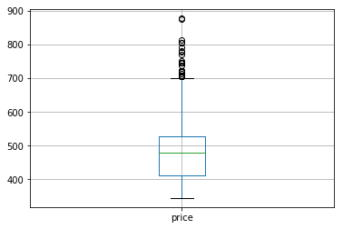

```python
df.boxplot('price')
```

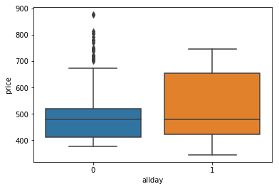

```python
sns.boxplot(x = 'allday', y = "price", data = df)
```

На боксплоте видно, что средняя цена сосредоточена где-то между 400 и 530 рублями. Медиана находится где-то на значении немногим меньше 500 рублей. Помимо этого, присутствует явный выброс от 700 до практически 900 рублей.

На графике из Seaborn заметна более высокая цена у круглосуочных аптек.

### Распределение цены

Посмотрим распределение подробнее.

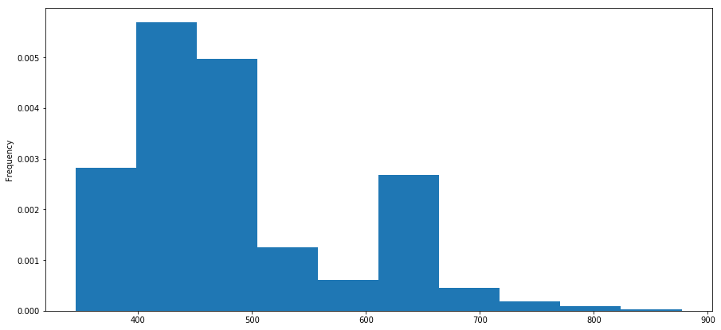

```python
df.price.plot.hist(density=True,
                   figsize=(15, 7),
                   legend=False)
```

На распределении видно, что в большинстве аптек лекарство Фенистил продаётся по цене до 500 рублей. В абсолютном большинстве цена варьируется от 400 до 500 рублей. Есть скачок в промежутке между 620 и 670 рублей, возможно, это аптеки центрального района, чуть позже мы сможем это увидеть, когда разместим точки на карте.

### Уникальные производители: всего 2 и в России они связаны

Проверим, может ли разброс в цене зависеть от производителя лекарства, так как под одним и тем же названием может выпускаться лекарство от разных фармацевтических компаний. Для этого посмотрим содержание столбца comment, в котором написан производитель лекарства. Так как база данных взята из агрегатора, то названия могу не совпадать.

Посмотрим уникальные значения столбца.

```python
set(df.comment)
```

```
{'NOVARTIS CONSUMER HEALTH Швейцарская Конфедерация',
 'Novartis Consumer Health',
 'Novartis Consumer Health S.A',
 'Novartis Consumer Health S.A. Швейцария',
 'Novartis Consumer Health/Швейцария',
 'Novartis Pharma AG',
 nan,
 'ГлаксоСмитКляин',
 'НОВАРТИС КОНСЬЮМЕР ХЕЛС',
 'Новартис',
 'Новартис Консьюмер Хелс (Швейцария)',
 'Новартис Консьюмер Хелс С.А. Швейцария',
 'Новартис Консьюмер Хелс С.А. Швейцарская Конфедерация',
 'Новартис ШВЕЙЦАРИЯ',
 'глаксосмиткляйн хелскеа ао произв. новартис консь',
 'новартис консьюмер хелс са',
 'новартис фарма аг произв. новартис фармасьютика с'}
```

Как мы видим, список получился действительно большим с немаленьким количеством вариаций написания двух компаний: Novartis International AG и GlaxoSmithKline. Швейцарская транснациональная фармацевтическая корпорация и британская фармацевтическая корпорация. Для создания веб-платформы нас не интересует конкретный производитель лекарства, поэтому не будем приводить список к единому знаменателю.

Можно предположить, что различие цены зависит от производителя. Но поверхностная проверка показала, что компании связаны между собой. С 2014 года у компаний существует совместное предприятие, а в 2018 британцы поглотили часть швейцарской корпорации. Поэтому на фактор производителя для данного лекарственного препарата можно не смотреть.

### Уникальные названия сетей

Изучив данные, можно приступать к их подготовке для создания маркеров на карте. Создадим список списков (или таблица CSV), где указаны ценовой коэффициент, координаты аптеки, название, адрес, часы работы, цена и принадлежность точки к определенной сети.

Для корректной работы фильтрации по аптечным сетям создадим короткие легенды каждой аптечной сети и сгенерируем из них список, по которому будем привязывать точки на карте, обрабатывая названия аптек.

Для прототипа веб-платформы обойдёмся первым словом названия (содержание столбца df.name до первого пробела), так мы сможем обойтись на данном этапе без поддержки индексируемой базы данных, разместив всё веб-приложение в виде простой HTML-страницы. Ещё это позволит обойти проблему с различной структурой названий.

```python
first_word = [x.split(' ')[0] for x in df.name]
uni = sorted(list(set(first_word)))
uni
```

```
['120/80',
 '36,6',
 'A.V.E',
 'А-Мега',
 'А5',
 'АСНА',
 'Абикон',
 'Аве',
 'Азбука',
 'Алоэ',
 'Альфа',
 'Аптека',
 'Аптеки',
 'Биотики',
 'ВИТРУМ',
 'Век',
 'Векфарм',
 'ГОРЗДРАВ',
 'Да',
 'Димфарм',
 'Добрая',
 'Доктор',
 'Долголет',
 'Здоровье',
 'Здравница',
 'ИРБИС',
 'ИФК',
 'Кардамон',
 'Катюшки',
 'Лада-доктор',
 'Линия',
 'Лорафарм',
 'МАРС',
 'МК-аптека',
 'Макфарма',
 'Мария',
 'Мелодия',
 'Мепико',
 'МосГорАптека',
 'НЕОФАРМ',
```

[output cut: 17 more lines]

```
 'Старый',
 'Сябры',
 'Тендор',
 'Торгфарм',
 'ФАРМАДАР',
 'ФармаСити',
 'ФармаТ',
 'Фармадар',
 'Фармастар',
 'ФармиКО',
 'Флория',
 'Хелвет',
 'Хорошая',
 'Эскулап',
 'Я']
```

В результате выполнения кода получим список с уникальными названиями всех аптечных сетей в городе Москва. Этот список будет выступать нашими техническими обозначениями, по которым в дальнейшем мы будем присваивать группу каждой точке для корректной работы фильтрации.

Как мы видим, к сожалению, некоторые аптеки имели название формата «Аптека …», «Аптеки …», «ООО …» или «Доктор …», за которыми скрываются аптеки различных сетей. На этапе создания прототипа платформы мы допустим эту погрешность, так как ни одна из крупных сетей не попала в эти нерепрезентативные группы. Все оригинальные названия можно будет увидеть при нажатии на точку.

Немного оптимизируем нашу работу и создадим часть кода HTML-страницы с помощью простого цикла на Python. Так как полученный ранее список будет выступать условными обозначениями для фильтрации аптек по аптечным сетям.

```python
for u in range(0, len(uni)):
    print('<option name="pharma" value="'+str(u)+'">'+uni[u]+'</option>')
```

```
<option name="pharma" value="0">120/80</option>
<option name="pharma" value="1">36,6</option>
<option name="pharma" value="2">A.V.E</option>
<option name="pharma" value="3">А-Мега</option>
<option name="pharma" value="4">А5</option>
<option name="pharma" value="5">АСНА</option>
<option name="pharma" value="6">Абикон</option>
<option name="pharma" value="7">Аве</option>
<option name="pharma" value="8">Азбука</option>
<option name="pharma" value="9">Алоэ</option>
<option name="pharma" value="10">Альфа</option>
<option name="pharma" value="11">Аптека</option>
<option name="pharma" value="12">Аптеки</option>
<option name="pharma" value="13">Биотики</option>
<option name="pharma" value="14">ВИТРУМ</option>
<option name="pharma" value="15">Век</option>
<option name="pharma" value="16">Векфарм</option>
<option name="pharma" value="17">ГОРЗДРАВ</option>
<option name="pharma" value="18">Да</option>
<option name="pharma" value="19">Димфарм</option>
<option name="pharma" value="20">Добрая</option>
<option name="pharma" value="21">Доктор</option>
<option name="pharma" value="22">Долголет</option>
<option name="pharma" value="23">Здоровье</option>
<option name="pharma" value="24">Здравница</option>
<option name="pharma" value="25">ИРБИС</option>
<option name="pharma" value="26">ИФК</option>
<option name="pharma" value="27">Кардамон</option>
<option name="pharma" value="28">Катюшки</option>
<option name="pharma" value="29">Лада-доктор</option>
<option name="pharma" value="30">Линия</option>
<option name="pharma" value="31">Лорафарм</option>
<option name="pharma" value="32">МАРС</option>
<option name="pharma" value="33">МК-аптека</option>
<option name="pharma" value="34">Макфарма</option>
<option name="pharma" value="35">Мария</option>
<option name="pharma" value="36">Мелодия</option>
<option name="pharma" value="37">Мепико</option>
<option name="pharma" value="38">МосГорАптека</option>
<option name="pharma" value="39">НЕОФАРМ</option>
```

[output cut: 17 more lines]

```
<option name="pharma" value="57">Старый</option>
<option name="pharma" value="58">Сябры</option>
<option name="pharma" value="59">Тендор</option>
<option name="pharma" value="60">Торгфарм</option>
<option name="pharma" value="61">ФАРМАДАР</option>
<option name="pharma" value="62">ФармаСити</option>
<option name="pharma" value="63">ФармаТ</option>
<option name="pharma" value="64">Фармадар</option>
<option name="pharma" value="65">Фармастар</option>
<option name="pharma" value="66">ФармиКО</option>
<option name="pharma" value="67">Флория</option>
<option name="pharma" value="68">Хелвет</option>
<option name="pharma" value="69">Хорошая</option>
<option name="pharma" value="70">Эскулап</option>
<option name="pharma" value="71">Я</option>
```

Как видно, каждой сети выдаётся уникальный индекс. По нему мы будем фильтровать нашу таблицу дальше. Всего получилось 72 сети.

Получив уникальные индексы для фильтрации, мы можем приступить к формированию необходимого для работы веб-платформы csv-файла. Как уже было написано, структура CSV-файла получилась такая:

- Ценовой коэффициент;
- Широта;
- Долгота;
- Название аптеки;
- Адрес;
- Время работы;
- Цена (временный пункт для тестирования системы);
- Аптечная сеть.

Все эти данные потребуются для формирования маркеров на карте, работы системы фильтрации по аптечной сети и создания всплывающих попапов с дополнительной информацией. Изучим имеющиеся столбцы в нашем csv-файле, чтобы понимать, к чему обращаться.

```python
df.columns
```

```
Index(['Unnamed: 0', 'adress', 'allday', 'comment', 'date', 'discount',
       'discount_comment', 'dop_info', 'dostavka', 'dostavka_info',
       'is_allow_orders', 'is_ishop', 'latitude', 'link', 'longitude', 'name',
       'order_url', 'orientir', 'pharm_id', 'price', 'shedule', 'skidki',
       'tel'],
      dtype='object')
```

### Итоговый массив для карты: %цены, lat, lon, имя, адрес, цена, группа

Теперь можно приступить к формированию списка списков, в котором каждый вложенный список будет одной аптекой (или точка на карте). На данном этапе ценовой коэффициент рассчитывался на основе цен на препарат.

**Формула:** *(цена-минимум)/(максимум-минимум)*

Таким образом мы получим, в каком процентном промежутке находится цена в данной точке.

Пройдёмся по всему массиву данных. При совпадении начала названия с элементом из нашего списка, присваиваем элементу соответствующую группу. После этого формируем необходимый список, обращаясь к элементам изначального csv-файла.

```python
coors = []
for i in range(0, len(df.longitude)):
    for u in uni:
        if u == df.name[i].split(' ')[0]:
            group = uni.index(u)
    coors.append([(df.price[i]-min(df.price))/(max(df.price)-min(df.price)), # ценновой коэффициент
                   df.latitude[i], # широта
                   df.longitude[i], # долгота
                   df.name[i], # название аптеки
                   df.adress[i], # адрес
                   df.shedule[i], # время работы
                   df.price[i], # цена
                   group]) # аптечная сеть
```

Получаем питоновский список списков с нужными нам данными:

```python
coors
```

```
[[0.0,
  55.701714,
  37.504483,
  'НЕОФАРМ Мичуринский',
  'г. Москва, Мичуринский пр-т, 20',
  nan,
  345.0,
  39],
 [0.041353383458646614,
  55.712633999999994,
  37.730652,
  'Векфарм',
  'Москва, ул. Люблинская,  д. 7/2 к. 1',
  nan,
  367.0,
  16],
 [0.05639097744360902,
  55.64784399999999,
  37.741782,
  'Векфарм',
  'Москва, Новочеркасский бульвар, д.57 к.1',
  nan,
  375.0,
  16],
 [0.06015037593984962,
  55.721899,
  37.402704,
  'Аптеки Столички Толбухина, 12/7',
  'г. Москва, ул. Толбухина, 12/7к1',
  'Пн-Пт: 08:00 - 21:00, Сб-Вс: 9 - 21',
  377.0,
  12],
 [0.06015037593984962,
  55.742478000000006,
  37.820915,
  'Аптеки Столички Кетчерская',
  'г. Москва, ул. Кетчерская, 4а',
  '8.00-21.00',
  377.0,
  12],
```

[output cut: 7946 more lines]

```
  37.640956,
  'ГОРЗДРАВ Аптека №1094',
  'Москва, Б. Переяславская, 11, корп. 1.',
  'будни 08:00-22:00; вых 09:00-21:00',
  480.0,
  17],
 [0.25375939849624063,
  55.773196,
  37.710988,
  'ГОРЗДРАВ Аптека №614',
  'Москва, Госпитальный вал, 18/1.',
  'круглосуточно',
  480.0,
  17],
 ...]
```

Как видно, в полученном списке не всегда присутствует время работы, это связано с тем, что оригинальная база данных собрана из разных источников и не претендует на полноценность, поэтому при создании веб-платформы нужно будет учесть этот момент, чтобы при сборке попапов код не ломался. Ценовой коэффициент выстроился от 0 до 1, как и планировалось.

Результат можно считать удовлетворительным. Нужно сохранить его в csv-файл, чтобы можно было использовать эти данные в нашем javascript коде, который будет встроен в html-страницу. Для этого используем простой код записи в файл и библиотеку csv, импортированную до этого.

```python
with open('coordinates.csv', 'w', newline="") as f:
    writer = csv.writer(f, delimiter=',')
    for i in range(0, len(coors)):
        writer.writerow(coors[i])
```

В таком виде мы его и встроим в итоговый код страницы, чтобы не понадобилось разворачивать серверное приложение для прототипа и всё работало запуском обычного HTML-файла.

## Этап 3: Создание веб-приложения (HTML + JavaScript)

Для работы с Open Street Map мы выбрали существующую библиотеку leaflet.js, так как она позволяет наносить на карту объекты и делать простейшую интерактивность. Этой функциональности с головой хватит для наглядного отображения имеющейся информации.

На карту нанесём попапы с информацией о выбранной аптеке. Поверх карты создадим элемент для фильтрации по аптечным сетям. В нём находится список всех сетей аптек. При выборе одной из них все точки на карте становятся прозрачнее, кроме тех, что принадлежат выбранной сети. Если выбрать опцию «all», то станут видны все опции. Функция работает, так как при генерации карты мы присвоим точкам классы с номером сети, к которой точка принадлежит.

В элементе с ID «map» будет генерироваться карта. 100% в ширину и на полный размер экрана в высоту.

В элементе с ID «picker-container» – элемент select со списком аптечных сетей.

Дальнейшая генерация происходит с помощью javascript кода.

Сначала мы генерируем карту с масштабом 11, и с центрированием на Москве.

```
var map = L.map('map').setView([55.7418, 37.6227], 11);
```

Далее мы делаем оформление карты. Задаем максимальный масштаб (18), цветовую схему (светлую). Leaflet.js работает на базе библиотеки MapBox, которая предоставляет несколько цветовых схем: светлая, темная, «уличная» и так далее. Была выбрана светлая, чтобы наши точки было видно лучше.

```
var osm=new L.tileLayer('https://api.mapbox.com/styles/v1/mapbox/{id}/tiles/{z}/{x}/{y}?access_token={accessToken}', {
    attribution: 'Map data © <a href="https://www.openstreetmap.org/">OpenStreetMap</a> contributors, <a href="https://creativecommons.org/licenses/by-sa/2.0/">CC-BY-SA</a>, Imagery © <a href="https://www.mapbox.com/">Mapbox</a>',
    maxZoom: 18,
    id: 'light-v9',
    accessToken: ‘’
}).addTo(map);
```

Далее мы загружаем нашу базу в переменную res. Поскольку база имеет пропущенные значения (nan), то задаем, чтобы они были заменены на пустые строки.

Далее создается цикл, который проходится по массиву и создает для каждого элемента соответствующую точку на карте. Цвет задается в зависимости от ценового коэффициента, как и радиус. Прозрачность точек – 50%, чтобы были видны наложения. И, самое важное, мы задаем класс точки в зависимости от того, к какой сети он принадлежит.

```
var marker = new L.circle(latLng, {
        color: color,
        fillColor: color,
        fillOpacity: .5,
        radius: res[i][0]*700+10,
        // radius: 100,
        className: String(res[i][7])
    }).addTo(map);
```

```
marker.bindPopup('<h4>'+res[i][3]+'</h4><p>'+res[i][4]+'</p><p>'+res[i][5]+'</p><p>'+res[i][6]+'</p>');
```

```
$('#picker').change(function() {
    var v = $(this).val();
    if (v != 'all') {
        $('path').css({'opacity': .1});
        $('.' + v).css({'opacity': 1});
    } else {
        $('path').css({'opacity': 1});
    }
});
```

В результате мы получаем интерактивное веб-приложение, запускаемой без серверного клиента. Вот полный код полученного веб-приложения, за вычетом нашей базы. Рабочий код можно посмотреть в файле *map1.html*.

```
<!DOCTYPE html>
<html>
<head>
    <title>Московские аптеки</title>
    <meta http-equiv="Content-Type" content="text/html; charset=utf-8" />
    <link rel="stylesheet" href="https://unpkg.com/leaflet@1.3.1/dist/leaflet.css" />
    <script src="https://unpkg.com/leaflet@1.3.1/dist/leaflet.js" charset="utf-8"></script>
</head>
<body>

<style> body {padding: 0; margin: 0;} #map {width: 100%;height: 100vh; }   </style>

<div id="map"></div>
<div id="picker-container" style="position: absolute; top: 70px; left: 70px; z-index: 999;">
    <h1 style="font-family: Helvetica, Arial">Московские аптеки</h1>
    <select id="picker" name="pharma" style="padding: 10px; border-radius: 10px;">
            <option name="pharma" value="all">Все</option>
            <option name="pharma" value="0">120/80</option>
            <option name="pharma" value="1">36,6</option>
            <option name="pharma" value="2">A.V.E</option>
            <option name="pharma" value="3">А-Мега</option>
            <option name="pharma" value="4">А5</option>
            <option name="pharma" value="5">АСНА</option>
            <option name="pharma" value="6">Абикон</option>
            <option name="pharma" value="7">Аве</option>
            <option name="pharma" value="8">Азбука</option>
            <option name="pharma" value="9">Алоэ</option>
            <option name="pharma" value="10">Альфа</option>
            <option name="pharma" value="11">Аптека</option>
            <option name="pharma" value="12">Аптеки</option>
            <option name="pharma" value="13">Биотики</option>
            <option name="pharma" value="14">ВИТРУМ</option>
            <option name="pharma" value="15">Век</option>
            <option name="pharma" value="16">Векфарм</option>
            <option name="pharma" value="17">ГОРЗДРАВ</option>
            <option name="pharma" value="18">Да</option>
            <option name="pharma" value="19">Димфарм</option>
            <option name="pharma" value="20">Добрая</option>
            <option name="pharma" value="21">Доктор</option>
            <option name="pharma" value="22">Долголет</option>
            <option name="pharma" value="23">Здоровье</option>
            <option name="pharma" value="24">Здравница</option>
            <option name="pharma" value="25">ИРБИС</option>
            <option name="pharma" value="26">ИФК</option>
            <option name="pharma" value="27">Кардамон</option>
            <option name="pharma" value="28">Катюшки</option>
            <option name="pharma" value="29">Лада-доктор</option>
            <option name="pharma" value="30">Линия</option>
            <option name="pharma" value="31">Лорафарм</option>
            <option name="pharma" value="32">МАРС</option>
            <option name="pharma" value="33">МК-аптека</option>
            <option name="pharma" value="34">Макфарма</option>
            <option name="pharma" value="35">Мария</option>
            <option name="pharma" value="36">Мелодия</option>
            <option name="pharma" value="37">Мепико</option>
            <option name="pharma" value="38">МосГорАптека</option>
            <option name="pharma" value="39">НЕОФАРМ</option>
            <option name="pharma" value="40">НОРМА</option>
            <option name="pharma" value="41">НордФарм</option>
            <option name="pharma" value="42">Нью</option>
            <option name="pharma" value="43">ОЗ</option>
            <option name="pharma" value="44">ОНФАРМ</option>
            <option name="pharma" value="45">ООО</option>
            <option name="pharma" value="46">Озерки</option>
            <option name="pharma" value="47">Оптимус-Мед</option>
            <option name="pharma" value="48">Первая</option>
            <option name="pharma" value="49">Первый</option>
            <option name="pharma" value="50">Планета</option>
            <option name="pharma" value="51">Поларт-Фарм</option>
            <option name="pharma" value="52">Радуга</option>
            <option name="pharma" value="53">Ригла</option>
            <option name="pharma" value="54">Самсон</option>
            <option name="pharma" value="55">Санитас</option>
            <option name="pharma" value="56">Солнышко</option>
            <option name="pharma" value="57">Старый</option>
            <option name="pharma" value="58">Сябры</option>
            <option name="pharma" value="59">Тендор</option>
            <option name="pharma" value="60">Торгфарм</option>
            <option name="pharma" value="61">ФАРМАДАР</option>
            <option name="pharma" value="62">ФармаСити</option>
            <option name="pharma" value="63">ФармаТ</option>
            <option name="pharma" value="64">Фармадар</option>
            <option name="pharma" value="65">Фармастар</option>
            <option name="pharma" value="66">ФармиКО</option>
            <option name="pharma" value="67">Флория</option>
            <option name="pharma" value="68">Хелвет</option>
            <option name="pharma" value="69">Хорошая</option>
            <option name="pharma" value="70">Эскулап</option>
            <option name="pharma" value="71">Я</option>
        </select>
</div>

<script src="https://code.jquery.com/jquery-3.4.1.min.js"></script>
<script charset="utf-8">
    var map = L.map('map').setView([55.7418, 37.6227], 11);
    var osm=new L.tileLayer('https://api.mapbox.com/styles/v1/mapbox/{id}/tiles/{z}/{x}/{y}?access_token={accessToken}', {
        attribution: 'Map data © <a href="https://www.openstreetmap.org/">OpenStreetMap</a> contributors, <a href="https://creativecommons.org/licenses/by-sa/2.0/">CC-BY-SA</a>, Imagery © <a href="https://www.mapbox.com/">Mapbox</a>',
        maxZoom: 18,
        id: 'light-v9',
        accessToken: 'pk.eyJ1IjoidGlrc2VuaWlhIiwiYSI6ImNqbzBobGpkZTAwd2Mza2xvZ2F4bTk1eG4ifQ.AWFalA05G9xWxDQqFOFBWA'
    }).addTo(map);

    var nan = '';
    var res = [[0.0, 55.701714, 37.504483, 'НЕОФАРМ Мичуринский', 'г. Москва, Мичуринский пр-т, 20', nan, 345.0, 39], [0.041353383458646614, 55.712633999999994, 37.730652, 'Векфарм', 'Москва, ул. Люблинская,  д. 7/2 к. 1', nan, 367.0, 16], [0.05639097744360902, 55.64784399999999, 37.741782, 'Векфарм', 'Москва, Новочеркасский бульвар, д.57 к.1', nan, 375.0, 16], [0.06015037593984962, 55.721899, 37.402704, 'Аптеки Столички Толбухина, 12/7', 'г. Москва, ул. Толбухина, 12/7к1', 'Пн-Пт: 08:00 - 21:00, Сб-Вс: 9 - 21', 377.0, 12], [0.06015037593984962, 55.742478000000006, 37.820915, 'Аптеки Столички Кетчерская', 'г. Москва, ул. Кетчерская, 4а', '8.00-21.00', 377.0, 12], [0.06015037593984962, 55.778715000000005, 37.665309, 'Аптеки Столички Краснопрудная', 'г. Москва, ул. Краснопрудная, 22-24', nan, 377.0, 12], [0.06015037593984962, 55.73256, 37.663737, 'Аптеки Столички Воронцовская', 'г. Москва, ул. Воронцовская, 48', '9.00-21.00', 377.0, 12], [0.06203007518796992, 55.84835699999999, 37.364965999999995, 'ГОРЗДРАВ Аптека №1465', 'Москва, Пятницкое ш., 25, корп. 1.', 'с 09:00 до 21:00', 378.0, 17], [0.06203007518796992, 55.86448000000001, 37.593938, 'ГОРЗДРАВ Аптека №1549', 'Москва, Каргопольская, 18, стр.1.', 'с 09:00 до 21:00', 378.0, 17], [0.06203007518796992, 55.642911, 37.346838, 'ГОРЗДРАВ  Аптека №705', 'Москва, Скульптора Мухиной, 6.', 'будни 09:00-22:00; вых 09:00-21:00', 378.0, 17], [0.06203007518796992, 55.816101, 37.461032, 'ГОРЗДРАВ Аптека №240', 'Москва, Габричевского ул, д. 10, корп. 2.', 'будни 08:00-22:00; вых 09:00-22:00', 378.0, 17], [0.06203007518796992, 55.80986899999999, 37.705419, 'ГОРЗДРАВ Аптека №1044', 'Москва, Краснобогатырская ул., д. 31, стр. 2.', 'Пн-Сб 09-21, Вс. 10-21', 378.0, 17], [0.06203007518796992, 55.847795999999995, 37.360052, 'ГОРЗДРАВ Аптека №281', 'Москва, Митинская, 40.', 'с 10:00 до 22:00', 378.0, 17], [0.06203007518796992, 55.677052, 37.747279999999996, 'ГОРЗДРАВ Аптека №786', 'Москва, Краснодарская ул., д. 16.', 'с 08:00 до 23:00', 378.0, 17], [0.06203007518796992, 55.677077000000004, 37.49948, 'Аптека 36 и 6', 'Москва Удальцова ул.  д.71  корп.3', nan, 378.0, 11], [0.06203007518796992, 55.789922, 37.677884999999996, 'Аптека 36 и 6', 'Москва Сокольническая площадь  д. 4  корп. 1-2.', nan, 378.0, 11], [0.06203007518796992, 55.622827, 37.506253, 'ГОРЗДРАВ Аптека №1362', 'Москва, Профсоюзная, 152, корп. 2, стр. 2.', 'с 08:00 до 22:00', 378.0, 17], [0.06203007518796992, 55.63756600000001, 37.657574, 'ГОРЗДРАВ', 'Москва, Кантемировская, 45.', 'будни 08:00-22:00; вых 09:00-22:00', 378.0, 17], [0.06203007518796992, 55.700008999999994, 37.768597, 'Аптеки Столички Юных Ленинцев', 'г. Москва,  ул. Юных Ленинцев, 73к1', '9.00-21.00', 378.0, 12], [0.06390977443609022, 55.799689, 37.793391, 'ОНФАРМ', 'Москва, ул. 7-я Парковая, д.19', '09.00 - 21.00', 379.0, 44], [0.06954887218045112, 55.794963, 37.798727, 'Аптеки Столички 9-я Парковая, 23', 'г. Москва, ул. 9-я Парковая, 23', '9-21', 382.0, 12], [0.07142857142857142, 55.742904, 37.418524, 'Аптеки Столички Ярцевская', 'г. Москва, Ярцевская, 29к3', 'Пн-Пт: 08:00 - 22:00, Сб-Вс: 9 - 21', 383.0, 12], [0.07330827067669173, 55.869763, 37.660377000000004, 'Аптеки Столички Менжинского', 'г. Москва, ул. Менжинского, 23к1', 'Пн-Пт: 08:00 - 21:00, Сб-Вс: 9 - 21', 384.0, 12], [0.07330827067669173, 55.864889, 37.597773, 'Долголет', 'Москва, Декабристов ул, д.8', 'Пн-Вс 08:00-20:00', 384.0, 22], [0.07518796992481203, 55.771742, 37.679053, 'ГОРЗДРАВ', 'Москва, Бауманская, 35/1.', 'буд. 07-23, вых 09-21', 385.0, 17], [0.07518796992481203, 55.709449, 37.661033, 'ГОРЗДРАВ', 'Москва, Автозаводская ул., д. 6.', 'будни 8-22, вых 9-21', 385.0, 17], [0.07518796992481203, 55.63194, 37.48322, 'ГОРЗДРАВ Аптека №937', 'Москва, Академика Виноградова ул., д. 1.', 'с 08:00 до 23:00', 385.0, 17], [0.07518796992481203, 55.680813, 37.672855, 'ГОРЗДРАВ Аптека №642', 'Москва, Судостроительная, 15, стр. 2.', 'с 09:00 до 21:00', 385.0, 17], [0.07518796992481203, 55.597149, 37.591943, 'ГОРЗДРАВ Аптека №110', 'Москва, Академика Янгеля, 6.', 'с 08:00 до 22:00', 385.0, 17], [0.07518796992481203, 55.718517000000006, 37.825010999999996, 'ГОРЗДРАВ', 'Москва, Вешняковская, д. 39 Б, стр. 1.', 'будни 08:00-21:00; вых 09:00-21:00', 385.0, 17], [0.07518796992481203, 55.886448, 37.66256, 'Аптеки Столички Грекова', 'г. Москва, ул. Грекова, 8', nan, 385.0, 12], [0.07518796992481203, 55.733112, 37.671669, 'ГОРЗДРАВ Аптека №532', 'Москва, Волгоградский пр-т, 1, стр. 1.', 'будни 08:00-22:00; вых 09:00-21:00', 385.0, 17], [0.07518796992481203, 55.716392000000006, 37.676214, 'ГОРЗДРАВ Аптека №554', 'Москва, Шарикоподшипниковская, 32.', 'будни 08:00-22:00; вых 09:00-21:00', 385.0, 17], [0.07518796992481203, 55.534688, 37.522071999999994, 'ГОРЗДРАВ', 'Москва, Южнобутовская, 91.', 'будни 08:00-21:00; вых 09:00-21:00', 385.0, 17], [0.07518796992481203, 55.638968000000006, 37.603999, 'ГОРЗДРАВ Аптека №156', 'Москва, мкр. Северное Чертаново, корп. 208.', 'с 09:00 до 22:00', 385.0, 17], [0.07518796992481203, 55.651571999999994, 37.598878000000006, 'ГОРЗДРАВ Аптека №125', 'Москва, Азовская, 25.', 'с 09:00 до 22:00', 385.0, 17], [0.07518796992481203, 55.749248, 37.800146000000005, 'ГОРЗДРАВ Аптека №562', 'Москва, Новогиреевская, 52.', 'будни 08:00-22:00; вых 09:00-21:00', 385.0, 17], [0.07518796992481203, 55.72079300000001, 37.785737, 'Фармадар Аптека №1374', 'Москва, Паперника ул., д. 7, корп. 2.', 'с 09:00 до 22:00', 385.0, 64], [0.07518796992481203, 55.657844999999995, 37.747729, 'ГОРЗДРАВ', 'Москва, Перерва, д. 56/2', 'с 09:00 до 22:00', 385.0, 17], [0.07518796992481203, 55.850964000000005, 37.412756, 'ГОРЗДРАВ Аптека №1512', 'Москва, Яна Райниса б-р, 26, корп.1.', 'с 08:00 до 22:30', 385.0, 17], [0.07518796992481203, 55.512036, 37.573663, 'ГОРЗДРАВ Аптека №1511', 'Москва, Щербинка, 40 лет Октября, 15/1.', 'с 09:00 до 21:00', 385.0, 17], [0.07518796992481203, 55.847680000000004, 37.356028, 'ГОРЗДРАВ Аптека №647', 'Москва, Митинская, 33.', 'с 08:30 до 21:30', 385.0, 17], [0.07518796992481203, 55.826377, 37.436246999999995, 'ГОРЗДРАВ Аптека №1504', 'Москва, Стратонавтов пр-д, 9.', 'с 08:00 до 22:00', 385.0, 17], [0.07518796992481203, 55.86050899999999, 37.483228999999994, 'Аптека 36 и 6', 'Москва  Смольная ул.  д. 24 А', nan, 385.0, 11], [0.07518796992481203, 55.57540899999999, 37.473248999999996, 'ГОРЗДРАВ Аптека №1598', 'Москва, Коммунарка п., Александры Монаховой, 5, корп.2.', 'с 09:00 до 22:00', 385.0, 17], [0.07518796992481203, 55.733579000000006, 37.86169, 'ГОРЗДРАВ Аптека №286', 'Москва, Салтыковская, 7Г.', 'с 10:00 до 22:00', 385.0, 17], [0.07518796992481203, 55.634471, 37.47483, 'Аптека 36 и 6', 'Москва  ул. Академика Варги д. 26Б.', nan, 385.0, 11], [0.07518796992481203, 55.65286700000001, 37.616215999999994, 'ГОРЗДРАВ', 'Москва, Чонгарский б-р, 5, корп. 1.', 'с 09:00 до 22:00', 385.0, 17], [0.07518796992481203, 55.689725, 37.574211, 'ГОРЗДРАВ', 'Москва, проспект 60-летия Октября, 18к1', 'с 09:00 до 21:00', 385.0, 17], [0.07518796992481203, 55.610829, 37.723951, 'ГОРЗДРАВ', 'Москва, Генерала Белова, 35.', 'круглосуточно', 385.0, 17], [0.07518796992481203, 55.639603, 37.35345, 'ГОРЗДРАВ Аптека №1586', 'Москва, Боровское ш., 36.', 'с 09:00 до 22:00', 385.0, 17], [0.07518796992481203, 55.635965, 37.672837, 'ГОРЗДРАВ', 'Москва, Кантемировская, 7, корп.1.', 'с 09:00 до 22:00', 385.0, 17], [0.07518796992481203, 55.604834, 37.599515999999994, 'ГОРЗДРАВ Аптека №1093', 'Москва, Кировоградская, 36, корп. 1.', 'с 09:00 до 22:00', 385.0, 17], [0.07518796992481203, 55.80486, 37.529412, 'ГОРЗДРАВ', 'Москва, Усиевича, 13.', 'с 09:00 до 21:00', 385.0, 17], [0.07518796992481203, 55.805356, 37.400809, 'Аптеки Столички Строгинский б-р', 'г. Москва, Строгинский бульвар, 7к1', '9:00 - 21:00', 385.0, 12], [0.07518796992481203, 55.549103, 37.554232, 'ГОРЗДРАВ Аптека №381', 'Москва, Скобелевская, 14.', 'с 09:00 до 21:00', 385.0, 17], [0.07518796992481203, 55.725899, 37.664464, 'ГОРЗДРАВ Аптека №477', 'Москва, Симоновский Вал, 9.', 'с 08:00 до 22:00', 385.0, 17], [0.07518796992481203, 55.63555899999999, 37.795565, 'Аптека 36 и 6', 'Москва  3-й квартал Капотня 13', nan, 385.0, 11], [0.07518796992481203, 55.815701000000004, 37.731838, 'ГОРЗДРАВ Аптека №171', 'Москва, Ивантеевская , 23.', 'будни 8-22, вых 9-21', 385.0, 17], [0.07518796992481203, 55.567117, 37.569764, 'ГОРЗДРАВ', 'Москва, Грина ул., д. 7.', 'будни 08:00-22:00; вых 09:00-22:00', 385.0, 17], [0.07518796992481203, 55.751031000000005, 37.783868, 'ГОРЗДРАВ Аптека №1120', 'Москва, 2-я Владимирская, 36.', 'будни 08:00-22:00; вых 09:00-21:00', 385.0, 17], [0.07518796992481203, 55.668447, 37.627795, 'ГОРЗДРАВ Аптека №623', 'Москва, Каширское шоссе, 4, корп. 1.', 'с 09:00 до 21:00', 385.0, 17], [0.07518796992481203, 55.750108999999995, 37.790516, 'ГОРЗДРАВ Аптека №591', 'Москва, Зеленый пр-т, 24, стр. 2.', 'будни 08:00-22:00; вых 09:00-22:00', 385.0, 17], [0.07518796992481203, 55.659870999999995, 37.618336, 'ГОРЗДРАВ', 'Москва, Варшавское ш., 66.', 'буд. 8:30-21:30, вых 9-21', 385.0, 17], [0.07518796992481203, 55.62171899999999, 37.611733, 'Аптека 36 и 6', 'Москва Кировоградская ул.  д. 9  корп. 4.', nan, 385.0, 11], [0.07518796992481203, 55.815630000000006, 37.715579, 'ГОРЗДРАВ Аптека №1604', 'Москва, Маршала Рокоссовского б-р, 31', 'будни 09:00-22:00; вых 09:00-21:00', 385.0, 17], [0.07518796992481203, 55.824066, 37.817654, 'ГОРЗДРАВ Аптека №1363', 'Москва, Уссурийская, 7.', 'будни 08:00-22:00; вых 09:00-21:00', 385.0, 17], [0.07518796992481203, 55.607356, 37.733715999999994, 'ГОРЗДРАВ', 'Москва, Елецкая, д. 15.', 'будни 08:00-22:00; вых 09:00-22:00', 385.0, 17], [0.07518796992481203, 55.808002, 37.635853000000004, 'ГОРЗДРАВ', 'Москва, Мира пр-т, 95, стр.1.', nan, 385.0, 17], [0.07518796992481203, 55.880832999999996, 37.693552000000004, 'ГОРЗДРАВ Аптека №1516', 'Москва, Малыгина, 9, стр.2.', 'с 09:00 до 21:00', 385.0, 17], [0.07518796992481203, 55.680037, 37.640605, 'ГОРЗДРАВ Аптека №1557', 'Москва, Нагатинская, 13, корп.1.', 'с 09:00 до 21:00', 385.0, 17], ...]
```

```
    for (var i=0; i<res.length; i++) {
        var latLng = new L.LatLng(res[i][1], res[i][2]);

        if (res[i][0] < .1) {
            var color = '#6f9dcc';
        } else if (res[i][0] < .3) {
            var color = '#5ec0d3';
        } else if (res[i][0] < .5) {
            var color = '#87ebf7';
        } else if (res[i][0] < .7) {
            var color = '#fce46c';
        } else {
            var color = '#eaa869';
        }


        var marker = new L.circle(latLng, {
            color: color,
            fillColor: color,
            fillOpacity: .5,
            radius: res[i][0]*700+10,
            // radius: 100,
            className: String(res[i][7])
        }).addTo(map).bindPopup('<h4>'+res[i][3]+'</h4><p>'+res[i][4]+'</p><p>'+res[i][5]+'</p><p>'+res[i][6]+'</p>');

    }

    $('#picker').change(function() {
        var v = $(this).val();
        if (v != 'all') {
            $('path').css({'opacity': .1});
            $('.' + v).css({'opacity': 1});
        } else {
            $('path').css({'opacity': 1});
        }
    })
</script>
</body>
</html>
```

## Этап 5: Очистка данных

Давайте избавимся от лишнего веса! Загрузим автоматически все csv в DataFrame.

```python
df_list = []
for i, drug in enumerate(os.listdir('data')):
    locals()['df' + str(i+1)] = pd.read_csv(os.path.join('data', drug)) #Автоматически загружаем csv в df1, df2 и т.д.
    df_list.append(locals()['df' + str(i+1)]) #Список из DataFrame
    print('Загрузил файл ' + os.path.join('data', drug) + ' в ' + 'df' + str(i+1))
```

```
Загрузил файл data\anaferondetskiy.csv в df1
Загрузил файл data\bifiform.csv в df2
Загрузил файл data\bronhomunalp.csv в df3
Загрузил файл data\fenistil.csv в df4
Загрузил файл data\ingavirin.csv в df5
Загрузил файл data\lazolvan.csv в df6
Загрузил файл data\lizobakt.csv в df7
Загрузил файл data\natriyadezoksiribonukleatderinat.csv в df8
Загрузил файл data\nazivin.csv в df9
Загрузил файл data\strepsils.csv в df10
Загрузил файл data\supradin.csv в df11
Загрузил файл data\vibrocil.csv в df12
```

Избавимся от лишних полей, запишем их в список.

```python
drop_list = ['orientir', 'allday', 'comment', 'discount', 'discount_comment', 'dop_info', 'dostavka', 'dostavka_info',
       'is_allow_orders', 'is_ishop', 'link', 'order_url', 'orientir', 'skidki', 'date']
```

```python
for dfit in df_list:
    dfit.loc[dfit['allday'] == 1, 'shedule'] = 'круглосуточно' #Заполняем пробелы во времени работы там, где круглосуточно
    dfit.drop(drop_list, axis=1, inplace=True) #удаляем ненужные поля
```

Получаем красивый DataFrame.

```python
df1
```

|  | Unnamed: 0 | adress | latitude | longitude | name | pharm_id | price | shedule | tel |
| --- | --- | --- | --- | --- | --- | --- | --- | --- | --- |
| 0 | 0 | Москва, Вавилова, 19. | 55.700182 | 37.580158 | А5 Аптека №868 | 9672 | 169.0 | с 09:00 до 19:00, сб и вс вых | 8(495)120-12-85 |
| 1 | 1 | Москва, ул. 8-я Текстильщиков, 19 | 55.702028 | 37.747361 | Аптеки Столички 8-я Текстильщиков | 12473 | 185.0 | 9.00-21.00 | (499) 648-83-07, 8 (800) 555-11-15 |
| 2 | 2 | Московская область, Москва, Мира пр-кт, д.118 | 55.810663 | 37.638296 | Мепико | 27278 | 190.0 | NaN | 74956484140 |
| 3 | 3 | г. Москва, Кировоградская ул., влад.22 Г | 55.614739 | 37.604358 | ООО &quot;ИФК Аптеки&quot; | 2633 | 190.0 | NaN | NaN |
| 4 | 4 | Московская область, Москва, Кировоградская ул,... | 55.614739 | 37.604358 | ИФК | 27244 | 190.0 | NaN | 784953150002*113 |
| 5 | 5 | г. Москва, Солнцево, ул. Авиаторов, 14 | 55.645334 | 37.398051 | НЕОФАРМ Авиаторов | 385 | 191.0 | 9.00-21.00 | 8 (495) 934-20-60 |
| 6 | 6 | г. Москва, Рублевское шоссе, 34к1 | 55.748382 | 37.417194 | Аптеки Столички Рублевское ш. | 409 | 191.0 | 9.00-21.00 | (499)649-61-85, 8 (800) 555-11-15 |
| 7 | 7 | г. Москва, ул. Сретенка, 27с1 | 55.771342 | 37.632134 | НЕОФАРМ Сретенка | 562 | 195.0 | 08:00-23:00 | 8(499)648-87-76 |
| 8 | 8 | г. Москва, Жулебинский бульвар, 25 | 55.689913 | 37.852266 | Аптеки Столички Жулебинский б-р | 629 | 199.0 | 9-21 | т (499) 649-38-14, 8 (800) 555-11-15 |
| 9 | 9 | Москва, Новотушинский, 6 | 55.837030 | 37.383193 | Планета здоровья Новотушинский | 3044 | 202.0 | NaN | +7 (495) 369-33-00 |
| 10 | 10 | Москва, Планерная, 12, корп. 1 | 55.862131 | 37.436580 | Планета здоровья Планерная | 3050 | 203.0 | NaN | +7 (495) 369-33-00 |
| 11 | 11 | Москва, Яблочкова, 21 | 55.819965 | 37.580238 | Планета здоровья Яблочкова | 3088 | 207.0 | NaN | +7 (495) 369-33-00 |
| 12 | 12 | Москва, Изюмская, 50 | 55.543857 | 37.559083 | Планета здоровья Изюмская | 3029 | 207.0 | NaN | +7 (495) 369-33-00 |
| 13 | 13 | Москва, Ленинградское ш., 8, корп. 2 | 55.817092 | 37.500360 | Планета здоровья Ленинградское 8 | 3039 | 208.0 | NaN | +7 (495) 369-33-00 |
| 14 | 14 | г. Москва, ул. Фруктовая, 8к3 | 55.661674 | 37.616512 | Аптеки Столички Фруктовая | 414 | 210.0 | 8.00-21.00 | (495) 739-74-8, 8 (800) 555-11-15 |
| 15 | 15 | г. Москва, ул. Енисейская, 17к1 | 55.867879 | 37.662614 | Аптеки Столички Енисейская | 633 | 210.0 | 9-00-21-00 | (499) 648-01-41, 8 (800) 555-11-15 |
| 16 | 16 | г. Москва, ул. Новогиреевская, 37с2 | 55.752845 | 37.799131 | Аптеки Столички Новогиреевская | 431 | 210.0 | 9.00-21.00 | (499)704-49-86, 8 (800) 555-11-15 |
| 17 | 17 | Москва, Б-р Маршала Рокоссовского, 30 | 55.816520 | 37.717043 | Аптеки Столички Б-р Маршала Рокоссовского, 30 | 12338 | 210.0 | 09:00-21:00 | (499) 648-85-70, 8 (800) 555-11-15 |
| 18 | 18 | Москва, ул. Профсоюзная, 18к1 | 55.683077 | 37.567258 | Аптеки Столички Профсоюзная, 18к1 | 12162 | 210.0 | 9-21 | (499) 648-08-79, 8 (800) 555-11-15 |
| 19 | 19 | г. Москва, ул. 5-я Кожуховская, 18к1 | 55.704894 | 37.673106 | Аптеки Столички 5-я Кожуховская | 545 | 210.0 | 9.00-21.00 | (499) 649-41-75, 8 (800) 555-11-15 |
| 20 | 20 | г. Москва, Открытое шоссе, 2к12 | 55.806909 | 37.727625 | Аптеки Столички Открытое шоссе | 434 | 210.0 | 9.00-21.00 | (499) 168-81-04, 8 (800) 555-11-15 |
| 21 | 21 | г. Москва, ул. Дудинка, 1 | 55.861297 | 37.688899 | Аптеки Столички Дудинка | 374 | 210.0 | Пн-Пт: 8.00-21.00,Сб-Вс: 8.00-20.00 | (499) 648-05-53, 8 (800) 555-11-15 |
| 22 | 22 | г. Москва, ул. Егора Абакумова, 9 | 55.879005 | 37.714474 | Аптеки Столички Егора Абакумова | 376 | 210.0 | Пн-Пт: 8.00 - 21.00, Сб-Вс: 9.00 - 21.00 | (499) 183-93-10, 8 (800) 555-11-15 |
| 23 | 23 | Москва, ул. Новочерёмушкинская, 11к2 | 55.686452 | 37.585089 | Аптеки Столички Новочерёмушкинская | 11998 | 210.0 | 9.00-21.00 | 8 (800) 555-11-15, (499) 648-85-32 |
| 24 | 24 | г. Москва, ул. Кунцевская, 13 | 55.730421 | 37.416970 | Аптеки Столички Кунцевская,13 | 881 | 210.0 | 9-21 | (499) 649-74-95 |
| 25 | 25 | г. Москва, ул. Героев Панфиловцев, 16к1 | 55.858822 | 37.424300 | Аптеки Столички Героев Панфиловцев | 446 | 210.0 | круглосуточно | 8(499)648-05-76, 8 (800) 555-11-15 |
| 26 | 26 | г. Москва, ул. Мантулинская, 2с1 | 55.757050 | 37.557529 | Аптеки Столички Мантулинская | 449 | 211.0 | Пн-Пт: 08:00 - 20:00, Сб-Вс: 9 - 21 | (499) 649-54-69 , 8 (800) 555-11-15 |
| 27 | 27 | г. Москва, ул. Нагатинская, 28 | 55.677418 | 37.657134 | Аптеки Столички Нагатинская | 399 | 212.0 | пон.-пят. 8:00-22:00 суб.-воск. 9:00-21:00 | (499) 612-25-68, 8 (800) 555-11-15 |
| 28 | 28 | г. Москва, ул. Профсоюзная, 138 | 55.627920 | 37.512020 | Аптеки Столички Профсоюзная, 138 | 380 | 212.0 | 9.00-21.00 | (495) 967-95-36, 8 (800) 555-11-15 |
| 29 | 29 | Москва, Ленинский пр-т, 40 | 55.702942 | 37.570258 | НЕОФАРМ Ленинский пр-т, 40 | 12594 | 212.0 | 9.00-21.00 | (499) 137-70-76; (499) 137-01-16 |
| ... | ... | ... | ... | ... | ... | ... | ... | ... | ... |
| 1638 | 1638 | Москва г. Большая Андроньевская ул. д.22 | 55.740314 | 37.670780 | А-Мега | 28719 | 417.0 | 10:00-22:00, без вых. | 8-968-778-16-26 |
| 1639 | 1639 | Москва г. Болотниковская ул. д. 30 | 55.658347 | 37.595609 | А-Мега | 28718 | 421.0 | 10:00-22:00, без вых. | 8-906-068-72-73 |
| 1640 | 1640 | Москва, Раменки ул, д.3 стр.1 | 55.693186 | 37.496848 | Энергия Здоровья | 30473 | 423.0 | Пн-Вс 10:00-21:00 | 74955931111 |
| 1641 | 1641 | Москва г. Мосфильмовская ул. д. 88к2 | 55.704093 | 37.493156 | Азбука LiFE | 28822 | 425.0 | 10:00-22:00, без вых. | 8-965-360-17-49 |
| 1642 | 1642 | Москва Малая Грузинская 3-9 | 55.762936 | 37.571120 | Самсон Фарма | 25953 | 425.0 | пн-пт: 08:00-22:00сб-вс: 09:00-21:00 | 8 (499) 215-74-60 |
| 1643 | 1643 | Московская область, Москва, Кутузовский пр-кт,... | 55.727927 | 37.476169 | Грагет Импорт | 27254 | 426.0 | NaN | 74952807047 |
| 1644 | 1644 | Москва Покровка 11 | 55.759208 | 37.643408 | Доктор Столетов | 25914 | 429.0 | 08:00-22:00 пн-вс; 10:00-22:00 сб-вс | 8(495)988-33-38 доб. |
| 1645 | 1645 | Москва Веерная 7 к.1 | 55.709617 | 37.474695 | Доктор Столетов | 25923 | 429.0 | круглосуточно | 8(495)988-33-38 доб. |
| 1646 | 1646 | Москва Тверская 22 | 55.767418 | 37.601169 | Доктор Столетов | 25881 | 429.0 | 08:00-23:00 пн-вс | 8(495)988-33-38 доб. |
| 1647 | 1647 | Москва Поляны 8 | 55.565605 | 37.556128 | Доктор Столетов | 25887 | 429.0 | 10:00-22:00 пн-вс | 8(495)988-33-38 доб. |
| 1648 | 1648 | Москва г. Пятницкое ш. д. 14 | 55.841625 | 37.386166 | Азбука LiFE | 28860 | 429.0 | 10:00-22:00, без вых. | 8(906)0687074 |
| 1649 | 1649 | Москва Березовой Рощи пр-д 8 | 55.787811 | 37.519467 | Доктор Столетов | 25903 | 429.0 | круглосуточно | 8(495)988-33-38 доб. |
| 1650 | 1650 | Москва Энтузиастов 12 корп.2 | 55.747363 | 37.707098 | Доктор Столетов | 25891 | 429.0 | 10:00-22:00 пн-вс | 8(495)988-33-38 доб. |
| 1651 | 1651 | Москва Комсомольский пр-т 28 | 55.726877 | 37.579645 | Доктор Столетов | 25907 | 429.0 | 08:00-22:00 пн-пт; 09:00-21:00 сб-вс | 8(495)988-33-38 доб. |
| 1652 | 1652 | Москва, Ленинский пр-т, д. 12. | 55.719561 | 37.597136 | 36,6 Аптека №588 | 9418 | 432.0 | с 09:00 до 23:00 | +7 (495) 797-63-36 |
| 1653 | 1653 | Москва г. Симферопольский б-р. д. 22 | 55.648367 | 37.604735 | Азбука LiFE | 28867 | 433.0 | 10:00-22:00, без вых. | 8-965-360-11-69 |
| 1654 | 1654 | Москва г. Марксистская ул. д. 38 | 55.733918 | 37.666584 | Азбука LiFE | 28810 | 435.0 | 10:00-22:00, без вых. | 8-903-754-28-68 |
| 1655 | 1655 | Москва Ленинградский пр-кт 23 | 55.783185 | 37.569216 | Самсон Фарма | 25945 | 435.0 | круглосуточно | 8 (495) 539-37-17 |
| 1656 | 1656 | Москва Лесная 5 | 55.777783 | 37.586877 | Доктор Столетов | 25870 | 438.0 | пн-пт:08.00-22.00; сб-вс: 10.00-22.00 | 8(495)988-33-38 доб. |
| 1657 | 1657 | Москва Малая Никитская 2/1 стр.1 | 55.757931 | 37.597423 | Доктор Столетов | 25900 | 442.0 | круглосуточно | 8(495)988-33-38 доб. |
| 1658 | 1658 | Москва 8-го Марта 1 стр.12 | 55.800726 | 37.554933 | Самсон Фарма | 25946 | 445.0 | круглосуточно | 8 (499) 649-02-27 |
| 1659 | 1659 | Москва г. Новинский б-р д. 31 | 55.757830 | 37.582511 | Азбука LiFE | 28828 | 445.0 | 10:00-22:00, без вых. | 8-965-360-17-87 |
| 1660 | 1660 | Москва г. Мытная ул. 7стр1 | 55.722142 | 37.618569 | Азбука LiFE | 28823 | 449.0 | 10:00-22:00, без вых. | 8-906-068-72-60 |
| 1661 | 1661 | Москва г. Островитянова ул. д. 2 | 55.645923 | 37.486041 | Азбука LiFE | 28843 | 450.0 | 10:00-22:00, без вых. | 8-965-360-13-30 |
| 1662 | 1662 | Москва г. Боровское ш. д. 56 | 55.634934 | 37.345760 | Азбука LiFE | 28730 | 452.0 | 10:00-22:00, без вых. | 8-965-360-04-45 |
| 1663 | 1663 | Москва г. Бартеневская ул. д. 12 | 55.551716 | 37.528154 | Да Здоров | 28710 | 457.0 | 10:00-22:00, без вых. | 9687781849 |
| 1664 | 1664 | Москва г. Покрышкина ул. д. 5 | 55.664436 | 37.469216 | Да Здоров | 28853 | 466.0 | 9:00-22:00, без вых. | 8-909-646-77-46 |
| 1665 | 1665 | Москва г. Николоямский пер. д. 2 | 55.748934 | 37.662821 | Азбука LiFE | 28827 | 467.0 | 10:00-22:00, без вых. | 8-965-360-03-05 |
| 1666 | 1666 | Москва г. Ленинский пр-кт дом 99 | 55.668635 | 37.518758 | Да Здоров | 28803 | 471.0 | 24 часа | 8-968-778-16-64 |
| 1667 | 1667 | Москва г. Удальцова ул. д. 42 | 55.683752 | 37.491063 | Да Здоров | 28877 | 497.0 | 8:00-23:00, без вых. | 8-906-068-70-38 |

1668 rows × 9 columns

Перезаписываем наши старые csv новыми.

```python
for i, drug in enumerate(os.listdir('data')):
    locals()['df' + str(i+1)].to_csv(os.path.join('data', drug))
```